# TPC3

João Dias

2023-10-02

Considere a variável aleatória X: número de telemóveis vendidos por dia numa pequena loja especializada. Admita que o comportamento de X pode ser descrito pela seguinte função de probabilidade x 0 1 2 3 4 5 6 𝑓(𝑥) 0.05 0.30 0.35 0.20 0.05 0.03 0.02

### 1.

(Teórica) Justifique que a função apresentada pode ser considerada uma função de probabilidade.

Pode considerar-se uma função de probabilidade porque se verifica que todos os valores de f(x) são não negativos (por outras palavras, para todos os valores de x: f(x)>=0) e a soma de todas as probabilidades é igual a 1 (por outras palavras: 0.05+0.30+0.35+0.20+0.05+0.03+0.02=1).

### 2.

Defina uma função em R que permita obter, para qualquer x real, a probabilidade de ocorrência de x. Use essa função para obter um vetor com os valores da função calculados nos pontos de probabilidade não nula.

```r
xe1 <- 0:6

fxe1 <- function(x) {
  if (x == 0) {prob <- 0.05}
  else if (x == 1) {prob <- 0.3}
  else if (x == 2) {prob <- 0.35}
  else if (x == 3) {prob <- 0.2}
  else if (x == 4) {prob <- 0.05}
  else if (x == 5) {prob <- 0.03}
  else if (x == 6) {prob <- 0.02}
  else {prob <- 0}
  return(prob)
}

fx_applied <- sapply(xe1,fxe1)
fx_applied
```

```
## [1] 0.05 0.30 0.35 0.20 0.05 0.03 0.02
```

### 3.

Represente graficamente a função de probabilidade.

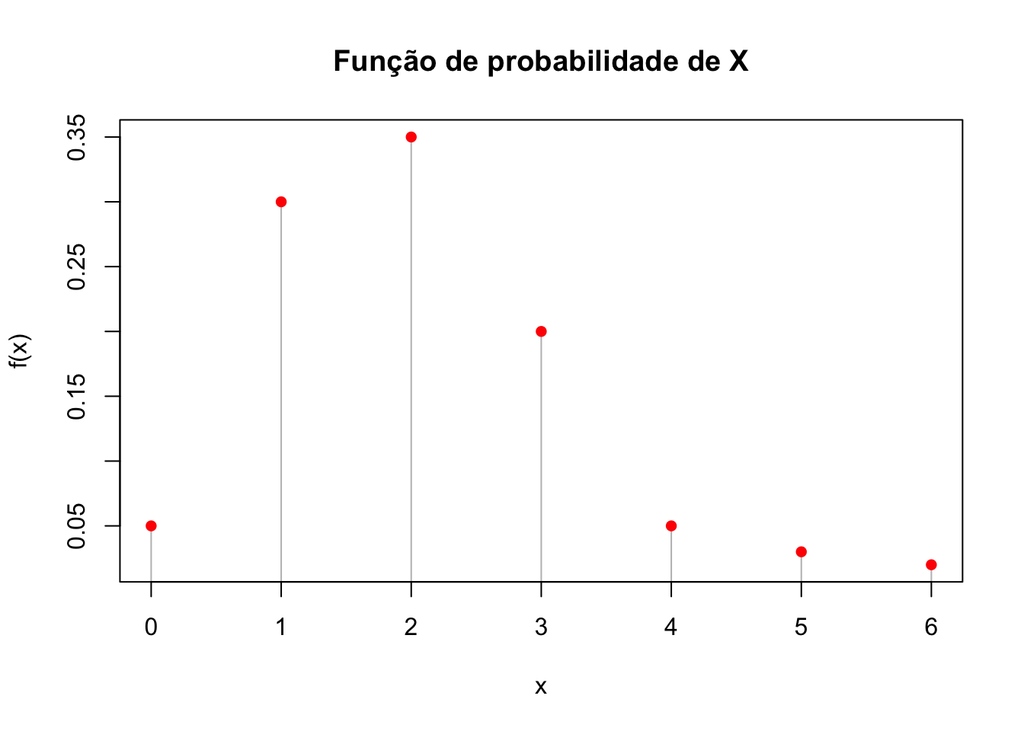

```r
plot (x=xe1,
      y=fx_applied,
      type="h",
      main="Função de probabilidade de X",
      xlab="x",
      ylab="f(x)",
      col="grey"
)

points(x=xe1,
       y=fx_applied,
       pch=16,
       col="red"
)
```

### 4.

. Obtenha a função de distribuição, F(𝑥) , nos pontos de probabilidade não nula de X.

```r
F_aux <- cumsum(fx_applied)

Fx_ex1 <- function(x) {
  (x < 1) * 0 +
  (1 <= x & x < 2) * F_aux[1] +
  (2 <= x & x < 3) * F_aux[2] +
  (3 <= x & x < 4) * F_aux[3] +
  (x >= 4) * 1
}

Fx_0 <- Fx_ex1(0)
Fx_2 <- Fx_ex1(2)
Fx_2.5 <- Fx_ex1(2.5)
Fx_4 <- Fx_ex1(4)
Fx_5 <- Fx_ex1(5)

print(paste("F(0):", Fx_0))
```

```
## [1] "F(0): 0"
```

```r
print(paste("F(2):", Fx_2))
```

```
## [1] "F(2): 0.35"
```

```r
print(paste("F(2.5):", Fx_2.5))
```

```
## [1] "F(2.5): 0.35"
```

```r
print(paste("F(4):", Fx_4))
```

```
## [1] "F(4): 1"
```

```r
print(paste("F(5):", Fx_5))
```

```
## [1] "F(5): 1"
```

### 5.

Defina uma função em R que permita obter, para qualquer x real, o valor da função de distribuição de X, F(𝑥), nesse ponto.

```r
FFx_ex1 <- stepfun(
  xe1,
  c(0, cumsum(fx_applied)),
  right = FALSE
)

# Exemplo de uso
FFx_0 <- FFx_ex1(0)
FFx_2 <- FFx_ex1(2)
FFx_2.5 <- FFx_ex1(2.5)
FFx_4 <- FFx_ex1(4)
FFx_5 <- FFx_ex1(5)

print(paste("F(0) usando stepfun:", FFx_0))
```

```
## [1] "F(0) usando stepfun: 0.05"
```

```r
print(paste("F(2) usando stepfun:", FFx_2))
```

```
## [1] "F(2) usando stepfun: 0.7"
```

```r
print(paste("F(2.5) usando stepfun:", FFx_2.5))
```

```
## [1] "F(2.5) usando stepfun: 0.7"
```

```r
print(paste("F(4) usando stepfun:", FFx_4))
```

```
## [1] "F(4) usando stepfun: 0.95"
```

```r
print(paste("F(5) usando stepfun:", FFx_5))
```

```
## [1] "F(5) usando stepfun: 0.98"
```

### 6.

Represente graficamente a função de distribuição.

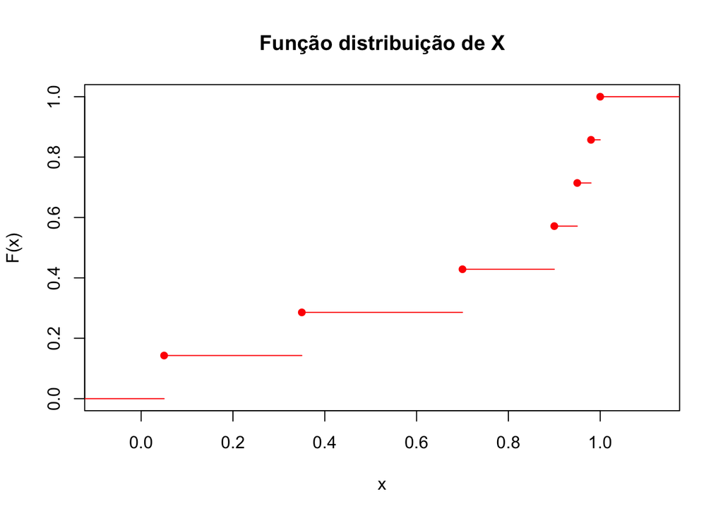

```r
plot.stepfun(
  FFx_ex1(xe1),
  verticals = FALSE,
  pch = 16,
  col = "red",
  main = "Função distribuição de X",
  xlab = "x",
  ylab = "F(x)"
)
```

### 7.

Qual a probabilidade de, em certo dia, serem vendidos mais do que 2 e não mais do que 5 telemóveis? Escrever a probabilidade pretendida em termos da variável aleatória definida, e calculá-la:

• Com recurso à função de probabilidade

```r
crfp <- fxe1(3) + fxe1(4) + fxe1(5)
crfp
```

```
## [1] 0.28
```

• Com recurso à função de distribuição

```r
crfd <- FFx_ex1(5) - FFx_ex1(2)
crfd
```

```
## [1] 0.28
```

### 8.

Repetir 6, para vendas entre 1 e 4 unidades (incluindo ambos os extremos).

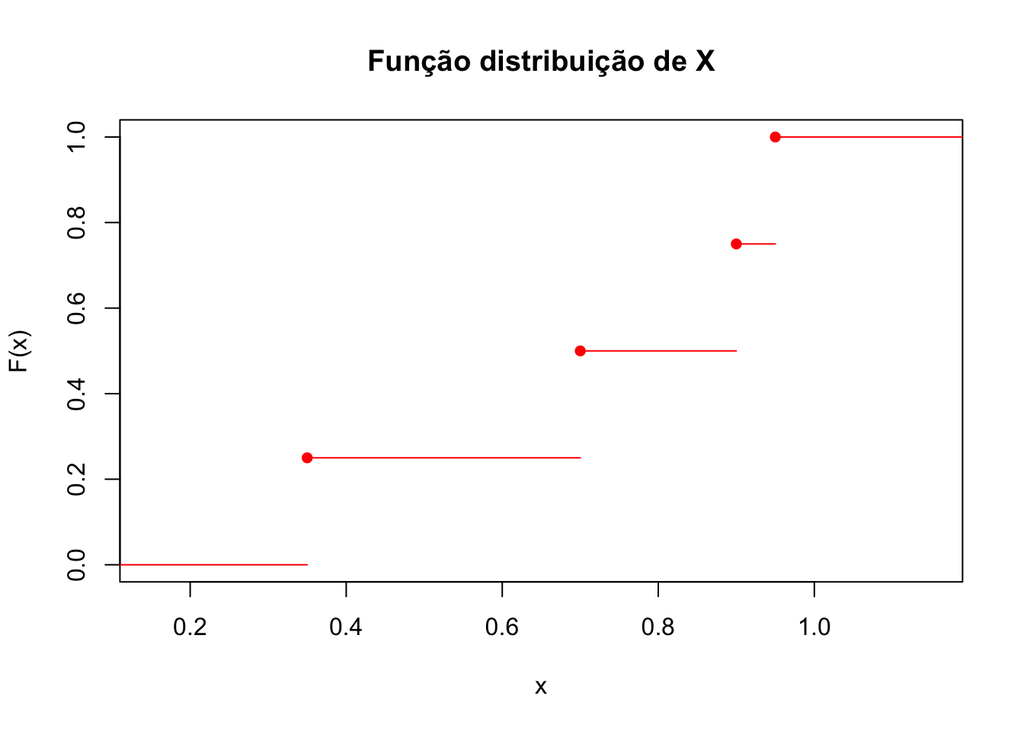

```r
plot.stepfun(
  FFx_ex1(1:4),
  verticals = FALSE,
  pch = 16,
  col = "red",
  main = "Função distribuição de X",
  xlab = "x",
  ylab = "F(x)"
)
```

### 9.

Repetir 6, para um número de telemóveis vendidos superior a 3.

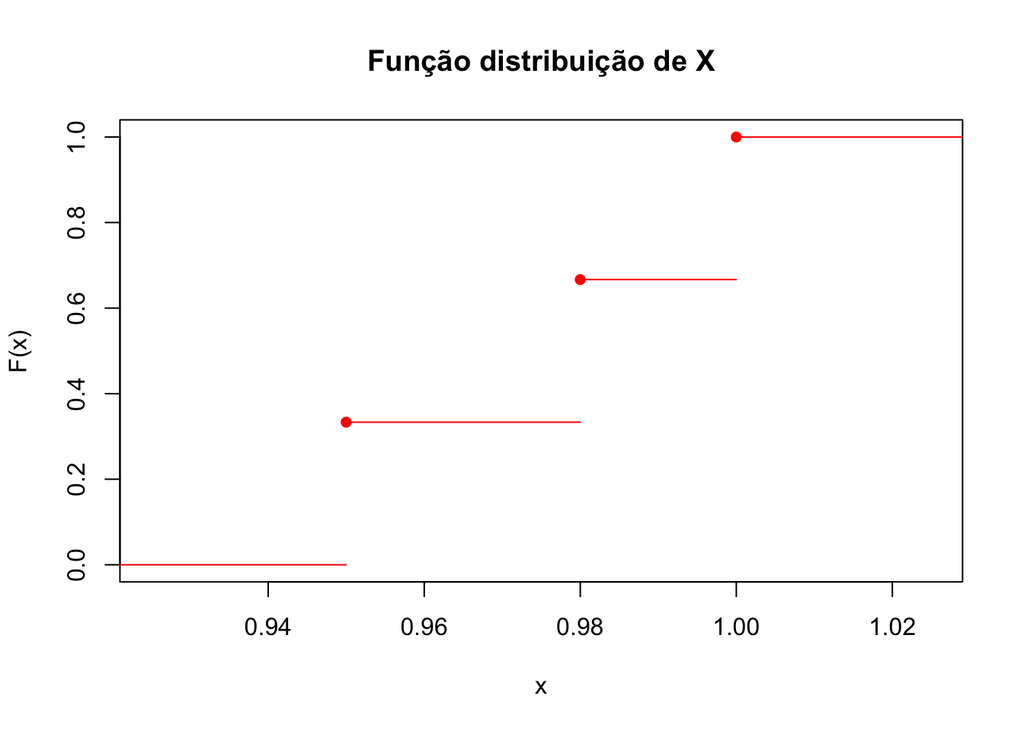

```r
plot.stepfun(
  FFx_ex1(4:6),
  verticals = FALSE,
  pch = 16,
  col = "red",
  main = "Função distribuição de X",
  xlab = "x",
  ylab = "F(x)"
)
```

### 10.

Calcular o valor esperado, a variância e o desvio-padrão de X.

```r
# Valor esperado
ve <- sum(xe1 * fx_applied)
ve
```

```
## [1] 2.07
```

```r
# Variância
v <- sum((xe1 - ve)^2 * fx_applied)
v
```

```
## [1] 1.4851
```

```r
# Desvio padrão
dp <- sqrt(v)
dp
```

```
## [1] 1.218647
```